```python
import json, os
import folium
import numpy as np
import seaborn as sns
import geopandas as gpd
from folium import plugins
import matplotlib.pyplot as plt
from collections import Counter
from scipy.stats import gaussian_kde
import scipy
```

```python
from shapely.geometry import Point,Polygon,LineString
```

# Introduction into handling geographical data

[John Snow](https://en.wikipedia.org/wiki/John_Snow) was an English physician, who was first to trace the source of a cholera outbreak in London's Soho district in 1854 using data visualization. In the following exercises, we are going to reconstruct the map of Snow with modern tools and explore some ideas of geographic data analysis.

[figure not shown]

Though there is a whole [R library](https://vincentarelbundock.github.io/Rdatasets/doc/HistData/Snow.pumps.html) dedicated to this dataset, we would like R users to also build the solutions (e.g. Voronoi cells) from scratch.

Further reading:

- https://en.wikipedia.org/wiki/1854_Broad_Street_cholera_outbreak
- https://www1.udel.edu/johnmack/frec682/cholera/cholera2.html
- https://www.theguardian.com/news/datablog/interactive/2013/mar/15/cholera-map-john-snow-recreated

The shapefile that will be used in these exercises are located at http://donboyes.com/2011/10/14/john-snow-and-serendipity/, but they are already downloaded into the `/v/courses/dataesp2023.public/Datasets/D-Shapes-Maps-Coordinates/shapes` directory.

```python
dataset_dir="/v/courses/2025-202425adatexplorcisvizualizci.public/Datasets/"
```

## Exercise 1

Load the death and the pump dataset into a tabular format! Have a look at the dataset's structure! The pump dataset contains the locations of wells. (Wells were used to obtain water for drinking, cooking etc. )

*The format of the files is called [shapefile](https://en.wikipedia.org/wiki/Shapefile), which is a format that is easily readable by the most common GIS (Geographic Information System) softwares. Shapefiles consist of many files, some of which store the geographic information, some the coordinate system description, some the additional attributes of the geographical objects. [geopandas](http://geopandas.org/) is able to read shapefiles natively into its base class GeoDataFrame, which has a similar API to that of `pandas` `DataFrames`. This is convenient, because we can use all of our previous knowledge of `pandas`.*

It is sometimes worth to have a look at a shapefile's content quickly. For Linux, [QGIS](https://www.qgis.org/en/site/about/index.html) is a powerful free GIS system, try it at home!

```python
deaths = gpd.read_file(dataset_dir+"Shapes-Maps-Coordinates/shapes/deaths_gcs.shp")
```

```python
deaths
```

|  | OBJECTID | X | Y | geometry |
| --- | --- | --- | --- | --- |
| 0 | 1 | 13.588010 | 11.095600 | POINT (-0.13585 51.51295) |
| 1 | 2 | 9.878124 | 12.559180 | POINT (-0.13877 51.51371) |
| 2 | 3 | 14.653980 | 10.180440 | POINT (-0.13502 51.51249) |
| 3 | 4 | 15.220570 | 9.993003 | POINT (-0.13457 51.51239) |
| 4 | 5 | 13.162650 | 12.963190 | POINT (-0.13617 51.51387) |
| ... | ... | ... | ... | ... |
| 573 | 574 | 12.438040 | 11.536670 | POINT (-0.13676 51.51318) |
| 574 | 575 | 15.050640 | 10.174120 | POINT (-0.1347 51.51248) |
| 575 | 576 | 17.271660 | 11.633800 | POINT (-0.13294 51.51317) |
| 576 | 577 | 12.426100 | 11.914420 | POINT (-0.13676 51.51336) |
| 577 | 578 | 15.018170 | 12.515810 | POINT (-0.13471 51.51363) |

578 rows × 4 columns

```python
brpump = gpd.read_file(dataset_dir+"Shapes-Maps-Coordinates/shapes/broad_st_pump_gcs.shp")
```

```python
brpump
```

|  | OBJECTID | X | Y | geometry |
| --- | --- | --- | --- | --- |
| 0 | 1 | 12.57136 | 11.72717 | POINT (-0.13664 51.5133) |

```python
pump = gpd.read_file(dataset_dir+"Shapes-Maps-Coordinates/shapes/pumps_gcs.shp")
```

```python
pump
```

|  | OBJECTID | X | Y | geometry |
| --- | --- | --- | --- | --- |
| 0 | 1 | 8.651201 | 17.891600 | POINT (-0.13962 51.5163) |
| 1 | 2 | 10.984780 | 18.517851 | POINT (-0.13773 51.51658) |
| 2 | 3 | 13.378190 | 17.394541 | POINT (-0.13585 51.51602) |
| 3 | 4 | 14.879830 | 17.809919 | POINT (-0.13463 51.5162) |
| 4 | 5 | 8.694768 | 14.905470 | POINT (-0.13966 51.51487) |
| 5 | 6 | 8.864416 | 12.753540 | POINT (-0.13959 51.51383) |
| 6 | 7 | 12.571360 | 11.727170 | POINT (-0.13664 51.5133) |
| 7 | 8 | 10.660970 | 7.428647 | POINT (-0.13829 51.51125) |
| 8 | 9 | 13.521460 | 7.958250 | POINT (-0.13598 51.51148) |
| 9 | 10 | 16.434891 | 9.252130 | POINT (-0.13361 51.51207) |
| 10 | 11 | 18.914391 | 9.737819 | POINT (-0.13161 51.51228) |
| 11 | 12 | 16.005110 | 5.046838 | POINT (-0.13407 51.51006) |
| 12 | 13 | 8.999440 | 5.101023 | POINT (-0.13968 51.51015) |

```python
pump.crs
```

```
<Geographic 2D CRS: EPSG:4326>
Name: WGS 84
Axis Info [ellipsoidal]:
- Lat[north]: Geodetic latitude (degree)
- Lon[east]: Geodetic longitude (degree)
Area of Use:
- name: World.
- bounds: (-180.0, -90.0, 180.0, 90.0)
Datum: World Geodetic System 1984 ensemble
- Ellipsoid: WGS 84
- Prime Meridian: Greenwich
```

## Exercise 2

Extract the latitudes and the longitudes for each row in both datasets as additional columns!

*In a `GeoDataFrame`, the `geometry` column contains geometry objects from the [`shapely`](https://toblerity.org/shapely/index.html) library. These objects have coordinate attributes, that is where latitude and longitude values are stored.*

The 'X' and 'Y' columns are coordinates in an arbitrary coordinate system and usually not part of a *shp* file.

The "crs()" method tells us in what coordinate system are the coordinates. Make sure that you use the right coordinate system, in which you can measure distances! If needed, project your points into a coordinate system where you can measure real distances (using e.g. `pyproj`), then create a meaningful visualization of the data!

*It is crucial to use the appropriate coordinate system for your purposes. For this exercise, the spherical coordinate system of lon, lat values is not convenient, since we cannot calculate distances in meters as easily as we would in a Cartesian coordinate system. Because of the Earth's shape, most projections distort distances at certain latitudes and longitudes.*

In GIS, different coordinate systems are called CRS (Coordinate Reference System), and have patented codes that define the origin, the projection etc. The usual lon, lat pairs are called the WGS84 system (you will need to find its epsg code first). A good choice for a Cartesian system is for example the Pseudo-Mercator projection ([epsg=3857](https://epsg.io/3857)). The `pyproj` library is especially lightweight to use in Python.

```python
pump["geometry"]
deaths["geometry"]
```

```
0      POINT (-0.13585 51.51295)
1      POINT (-0.13877 51.51371)
2      POINT (-0.13502 51.51249)
3      POINT (-0.13457 51.51239)
4      POINT (-0.13617 51.51387)
                 ...
573    POINT (-0.13676 51.51318)
574     POINT (-0.1347 51.51248)
575    POINT (-0.13294 51.51317)
576    POINT (-0.13676 51.51336)
577    POINT (-0.13471 51.51363)
Name: geometry, Length: 578, dtype: geometry
```

```python
dlatitudes = []
dlongitudes = []
for xy in deaths['geometry']:
    dlatitudes.append(xy.coords[0][1])
    dlongitudes.append(xy.coords[0][0])
deaths['lat'] = dlatitudes
deaths["long"] = dlongitudes
```

```python
platitudes = []
plongitudes = []
for yx in pump['geometry']:
    platitudes.append(yx.coords[0][1])
    plongitudes.append(yx.coords[0][0])
pump['lat'] = platitudes
pump["long"] = plongitudes
```

```python
display(deaths.head())
```

|  | OBJECTID | X | Y | geometry | lat | long |
| --- | --- | --- | --- | --- | --- | --- |
| 0 | 1 | 13.588010 | 11.095600 | POINT (-0.13585 51.51295) | 51.512950 | -0.135851 |
| 1 | 2 | 9.878124 | 12.559180 | POINT (-0.13877 51.51371) | 51.513712 | -0.138770 |
| 2 | 3 | 14.653980 | 10.180440 | POINT (-0.13502 51.51249) | 51.512488 | -0.135016 |
| 3 | 4 | 15.220570 | 9.993003 | POINT (-0.13457 51.51239) | 51.512389 | -0.134570 |
| 4 | 5 | 13.162650 | 12.963190 | POINT (-0.13617 51.51387) | 51.513870 | -0.136173 |

```python
deaths_proj = deaths['geometry'].to_crs({'init': 'epsg:3857'})
pumps_proj = pump['geometry'].to_crs({'init': 'epsg:3857'})
```

```python
dlat_proj = []
dlong_proj = []
yx = 0
for yx in deaths['geometry']:
    dlat_proj.append(yx.coords[0][1])
    dlong_proj.append(yx.coords[0][0])
deaths['dlat_proj'] = dlat_proj
deaths["dlong_proj"] = dlong_proj

plat_proj = []
plong_proj = []
yx = 0
for yx in pump['geometry']:
    plat_proj.append(yx.coords[0][1])
    plong_proj.append(yx.coords[0][0])
pump['plat_proj'] = plat_proj
pump["plong_proj"] = plong_proj
```

```python
display(deaths.head())
display(pump.head())
```

|  | OBJECTID | X | Y | geometry | lat | long | dlat_proj | dlong_proj |
| --- | --- | --- | --- | --- | --- | --- | --- | --- |
| 0 | 1 | 13.588010 | 11.095600 | POINT (-0.13585 51.51295) | 51.512950 | -0.135851 | 51.512950 | -0.135851 |
| 1 | 2 | 9.878124 | 12.559180 | POINT (-0.13877 51.51371) | 51.513712 | -0.138770 | 51.513712 | -0.138770 |
| 2 | 3 | 14.653980 | 10.180440 | POINT (-0.13502 51.51249) | 51.512488 | -0.135016 | 51.512488 | -0.135016 |
| 3 | 4 | 15.220570 | 9.993003 | POINT (-0.13457 51.51239) | 51.512389 | -0.134570 | 51.512389 | -0.134570 |
| 4 | 5 | 13.162650 | 12.963190 | POINT (-0.13617 51.51387) | 51.513870 | -0.136173 | 51.513870 | -0.136173 |

|  | OBJECTID | X | Y | geometry | lat | long | plat_proj | plong_proj |
| --- | --- | --- | --- | --- | --- | --- | --- | --- |
| 0 | 1 | 8.651201 | 17.891600 | POINT (-0.13962 51.5163) | 51.516303 | -0.139621 | 51.516303 | -0.139621 |
| 1 | 2 | 10.984780 | 18.517851 | POINT (-0.13773 51.51658) | 51.516582 | -0.137734 | 51.516582 | -0.137734 |
| 2 | 3 | 13.378190 | 17.394541 | POINT (-0.13585 51.51602) | 51.516019 | -0.135846 | 51.516019 | -0.135846 |
| 3 | 4 | 14.879830 | 17.809919 | POINT (-0.13463 51.5162) | 51.516205 | -0.134632 | 51.516205 | -0.134632 |
| 4 | 5 | 8.694768 | 14.905470 | POINT (-0.13966 51.51487) | 51.514867 | -0.139665 | 51.514867 | -0.139665 |

```python
lat_c = np.mean([np.mean(deaths.dlat_proj), np.mean(pump.plat_proj)])
long_c = np.mean([np.mean(deaths.dlong_proj), np.mean(pump.plong_proj)])
```

```python
deaths['lat_proj_rs'] = deaths.dlat_proj - lat_c
deaths['long_proj_rs'] = deaths.dlong_proj - long_c

pump['lat_proj_rs'] = pump.plat_proj - lat_c
pump['long_proj_rs'] = pump.plong_proj - long_c
```

```python
display(deaths.head())
display(pump.head())
```

|  | OBJECTID | X | Y | geometry | lat | long | dlat_proj | dlong_proj | lat_proj_rs | long_proj_rs |
| --- | --- | --- | --- | --- | --- | --- | --- | --- | --- | --- |
| 0 | 1 | 13.588010 | 11.095600 | POINT (-0.13585 51.51295) | 51.512950 | -0.135851 | 51.512950 | -0.135851 | -0.000384 | 0.000636 |
| 1 | 2 | 9.878124 | 12.559180 | POINT (-0.13877 51.51371) | 51.513712 | -0.138770 | 51.513712 | -0.138770 | 0.000379 | -0.002283 |
| 2 | 3 | 14.653980 | 10.180440 | POINT (-0.13502 51.51249) | 51.512488 | -0.135016 | 51.512488 | -0.135016 | -0.000845 | 0.001471 |
| 3 | 4 | 15.220570 | 9.993003 | POINT (-0.13457 51.51239) | 51.512389 | -0.134570 | 51.512389 | -0.134570 | -0.000944 | 0.001917 |
| 4 | 5 | 13.162650 | 12.963190 | POINT (-0.13617 51.51387) | 51.513870 | -0.136173 | 51.513870 | -0.136173 | 0.000536 | 0.000315 |

|  | OBJECTID | X | Y | geometry | lat | long | plat_proj | plong_proj | lat_proj_rs | long_proj_rs |
| --- | --- | --- | --- | --- | --- | --- | --- | --- | --- | --- |
| 0 | 1 | 8.651201 | 17.891600 | POINT (-0.13962 51.5163) | 51.516303 | -0.139621 | 51.516303 | -0.139621 | 0.002970 | -0.003134 |
| 1 | 2 | 10.984780 | 18.517851 | POINT (-0.13773 51.51658) | 51.516582 | -0.137734 | 51.516582 | -0.137734 | 0.003249 | -0.001247 |
| 2 | 3 | 13.378190 | 17.394541 | POINT (-0.13585 51.51602) | 51.516019 | -0.135846 | 51.516019 | -0.135846 | 0.002686 | 0.000641 |
| 3 | 4 | 14.879830 | 17.809919 | POINT (-0.13463 51.5162) | 51.516205 | -0.134632 | 51.516205 | -0.134632 | 0.002871 | 0.001855 |
| 4 | 5 | 8.694768 | 14.905470 | POINT (-0.13966 51.51487) | 51.514867 | -0.139665 | 51.514867 | -0.139665 | 0.001533 | -0.003178 |

## Exercise 3

How many deaths were within a given radius around the wells? Test for a series of radiuses.

```python
# this cell was written with the help of my good friend chatgpt
# Initialize an empty dictionary to store distances
dist = {}

# Iterate over each row in the 'pumps' DataFrame
for pump_index, pump_row in pump.iterrows():
    pump_id = pump_row.OBJECTID
    pump_lat = pump_row.lat_proj_rs
    pump_long = pump_row.long_proj_rs

    distances = []

    for death_index, death_row in deaths.iterrows():
        death_lat = death_row.lat_proj_rs
        death_long = death_row.long_proj_rs

        distance = np.sqrt((pump_lat - death_lat) ** 2 + (pump_long - death_long) ** 2)

        distances.append(distance)

    sorted_distances = sorted(distances)

    dist[pump_id] = sorted_distances
```

```python
my_dist = []
for i in range(1,len(dist)+1):
    my_dist.append(dist[i])
min_r = np.min(my_dist)
max_r = np.max(my_dist)
```

```python
print(min_r,max_r)
```

```
9.154307228577124e-05 0.008933601356156179
```

```python
# Create
radius = np.linspace(min_r, max_r, 1000)

# Count number of death in specific radius
dist_count = {}
for idx, dists in dist.items():
    dist_count[idx] = [np.sum([d < r for d in dists]) for r in radius]
```

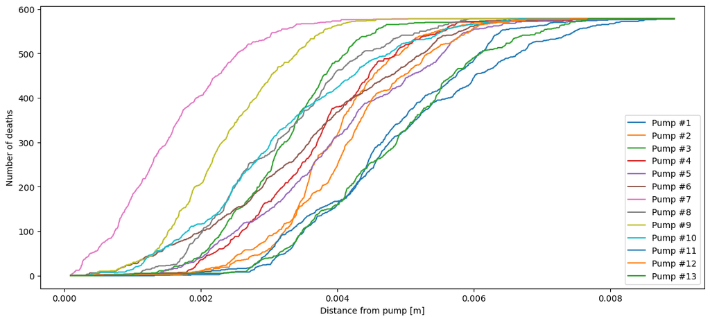

```python
plt.figure(figsize=(14,6))
for idx, dists in dist_count.items():
    plt.plot(radius, dists, label='Pump #{0}'.format(idx))

plt.xlabel('Distance from pump [m]')
plt.ylabel('Number of deaths')

plt.legend(loc='lower right')

plt.show()
```

## Exercise 4

Put both the deaths and the pumps on a zoomable map that has a base layer from a tile server different from that of the default settings of your chosen method. Set the appropriate map center and zoom level. Use different markers for the deaths and the pumps datasets.

*Try folium in Python, or Leaflet in R or JS. Display the map here in the notebook.*

```python
lat_c = np.mean([np.mean(deaths.lat), np.mean(pump.lat)])
long_c = np.mean([np.mean(deaths.long), np.mean(pump.long)])

JS_map = folium.Map(location=[lat_c, long_c], zoom_start=18, tiles='CartoDB Positron')


for _, death in deaths.iterrows():
    marker = folium.Marker(location=[death.lat, death.long],
                           icon=folium.Icon(icon='ambulance', prefix='fa', color='black'),
                           popup='Death #{0}'.format(death.OBJECTID))
    marker.add_to(JS_map)

for _, pumps in pump.iterrows():
    marker = folium.Marker(location=[pumps.lat, pumps.long],
                           icon=folium.Icon(icon='glyphicon-tint', color='blue'),
                           popup='Pump #{0}'.format(pumps.OBJECTID))
    marker.add_to(JS_map)

display(JS_map)
```

Make this Notebook Trusted to load map: File -> Trust Notebook

[interactive chart not shown]

## Exercise 5

Calculate the Voronoi cells for the pumps, and count the number of deaths falling into each of the cells. Create a bar chart of the number of deaths in each cell. Pinpoint the possible source of the infection.

*Store the Voronoi cells in a GeoDataFrame, then you can easily do a spatial join (e.g. testing whether a polygon in the Voronoi dataframe contains a point from the death dataframe).*

```python
X_d = deaths.lat_proj_rs.values
Y_d = deaths.long_proj_rs.values

X_p = pump.lat_proj_rs.values
Y_p = pump.long_proj_rs.values
```

```python
min_x = np.min(np.concatenate((X_d, X_p)))
max_x = np.max(np.concatenate((X_d, X_p)))
min_y = np.min(np.concatenate((Y_d, Y_p)))
max_y = np.max(np.concatenate((Y_d, Y_p)))

size_x = max_x - min_x
size_y = max_y - min_y
```

```python
vor = scipy.spatial.Voronoi(np.vstack([X_p, Y_p]).T)
```

```python
from scipy.spatial import voronoi_plot_2d
from matplotlib.lines import Line2D
```

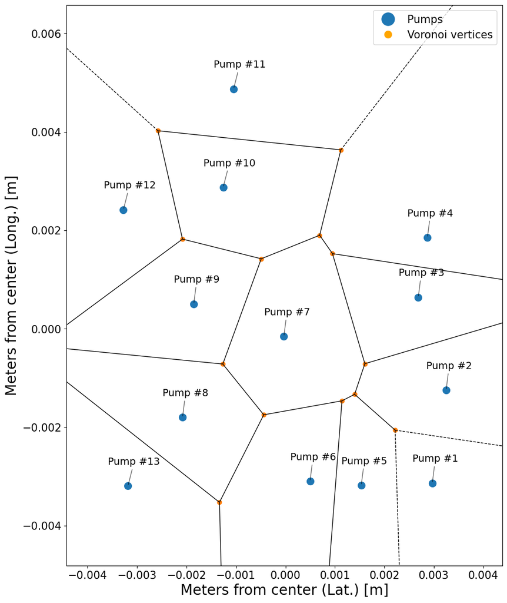

```python
nrows, ncols = 1, 1
f_size = 11
fig, ax = plt.subplots(nrows=nrows, ncols=ncols,
                       figsize=(ncols * f_size, nrows * f_size * size_y / size_x))

axis_label_size = 20
axis_tick_size = 15
legend_font_size = 15
pump_marker_size = 20

voronoi_plot_2d(vor, ax=ax, point_size=20)

for _, p in pump.iterrows():
    ax.annotate(f'Pump #{p.OBJECTID}',
                xy=(p.lat_proj_rs, p.long_proj_rs),
                xycoords='data',
                xytext=(-28, 30), textcoords='offset points', size=14,
                arrowprops=dict(arrowstyle='-', color='black', alpha=0.6))  # Draw an arrow to the pump

ax.set_xlabel('Meters from center (Lat.) [m]', fontsize=axis_label_size)
ax.set_ylabel('Meters from center (Long.) [m]', fontsize=axis_label_size)
ax.tick_params(axis='both', labelsize=axis_tick_size)

border_multiplier = 1.35
ax.set_xlim(border_multiplier * min_x, border_multiplier * max_x)
ax.set_ylim(border_multiplier * min_y, border_multiplier * max_y)

custom_handles = [
    Line2D([0], [0], marker='o', color='w', label='Pumps',
           markerfacecolor='C0', markersize=pump_marker_size),
    Line2D([0], [0], marker='o', color='w', label='Voronoi vertices',
           markerfacecolor='orange', markersize=12)
]
ax.legend(handles=custom_handles, loc='upper right', fontsize=legend_font_size)

# === Show the Plot ===
plt.show()
```

```python
voronoi_kdtree = scipy.spatial.cKDTree(np.vstack([X_p, Y_p]).T)
closest_pump_dist, closest_pump_regions = voronoi_kdtree.query(np.vstack([X_d, Y_d]).T)
```

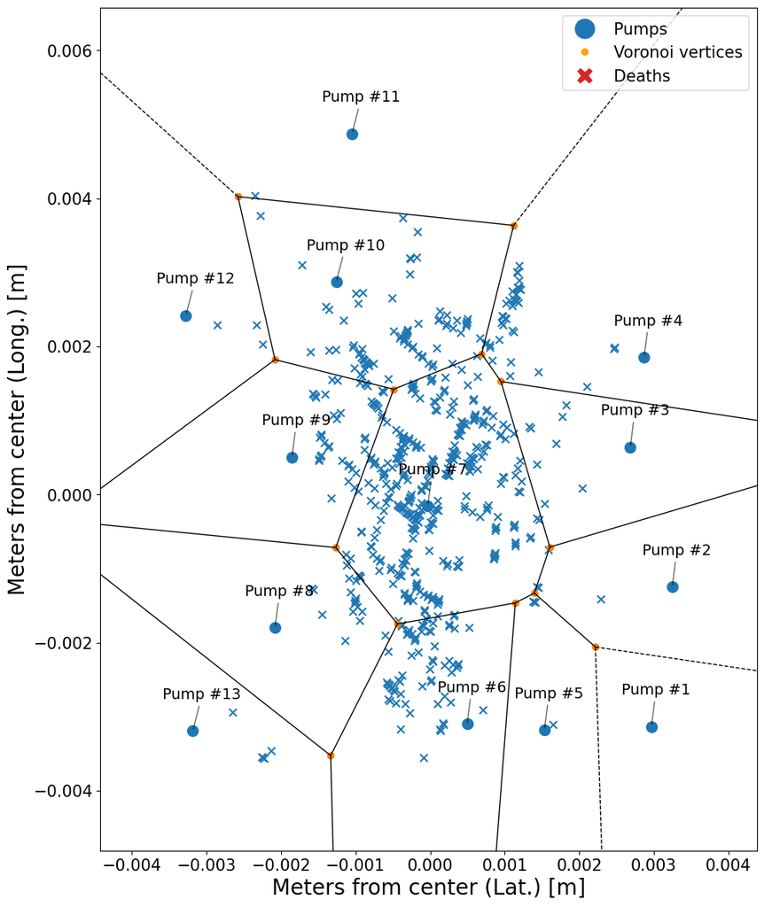

```python
# Visualize the Voronoi cells
nrows = 1
ncols = 1
f_size = 11
fig, axes = plt.subplots(nrows=nrows, ncols=ncols, figsize=(ncols*f_size, nrows*f_size*size_y/size_x))

axislabelsize = 20
axisticksize = 15
axislegendsize = 15
s_p_radius = 20
s_d_radius = 7

axes.scatter(X_d, Y_d, marker='x', s=s_d_radius**2)

scipy.spatial.voronoi_plot_2d(vor, point_size=s_p_radius, ax=axes)

# Annotate pumps
for _, p in pump.iterrows():
    axes.annotate('Pump #{0}'.format(p.OBJECTID),
                  xy=(p.lat_proj_rs, p.long_proj_rs), xycoords='data',
                  xytext=(-28, 30), textcoords='offset points', size='14',
                  arrowprops=dict(arrowstyle='-', color='black', alpha=0.6))

axes.set_xlabel('Meters from center (Lat.) [m]', fontsize=axislabelsize)
axes.set_ylabel('Meters from center (Long.) [m]', fontsize=axislabelsize)
axes.tick_params(axis='both', which='major', labelsize=axisticksize)

# Set border limits
mult = 1.35
axes.set_xlim(mult*min_x, mult*max_x)
axes.set_ylim(mult*min_y, mult*max_y)

# Create figure legend
handles = [
    Line2D([0], [0], marker='o', color='w', label='Pumps', markerfacecolor='C0', markersize=s_p_radius),
    Line2D([0], [0], marker='.', color='w', label='Voronoi vertices', markerfacecolor='orange', markersize=16),
    Line2D([0], [0], marker='X', color='w', label='Deaths', markerfacecolor='tab:red', markersize=16, lw=1)
]
axes.legend(handles=handles, loc='upper right', fontsize=axislegendsize)

plt.show()
```

```python
def voronoi_finite_polygons_2d(vor, radius=None):


    new_regions = []
    new_vertices = vor.vertices.tolist()

    center = vor.points.mean(axis=0)
    if radius is None:
        radius = np.max(np.ptp(vor.points, axis=0))


    all_ridges = {}
    for (p1, p2), (v1, v2) in zip(vor.ridge_points, vor.ridge_vertices):
        all_ridges.setdefault(p1, []).append((p2, v1, v2))
        all_ridges.setdefault(p2, []).append((p1, v1, v2))

    for point_idx, region_idx in enumerate(vor.point_region):
        region = vor.regions[region_idx]

        if all(v >= 0 for v in region):
            new_regions.append(region)
            continue

        ridges = all_ridges[point_idx]
        new_region = [v for v in region if v >= 0]

        for p2, v1, v2 in ridges:
            if v2 < 0:
                v1, v2 = v2, v1
            if v1 >= 0:
                continue

            # Compute direction for "far point" using perpendicular normal
            t = vor.points[p2] - vor.points[point_idx]  # tangent vector
            t /= np.linalg.norm(t)
            n = np.array([-t[1], t[0]])  # perpendicular (normal vector)

            midpoint = vor.points[[point_idx, p2]].mean(axis=0)
            direction = np.sign(np.dot(midpoint - center, n)) * n
            far_point = vor.vertices[v2] + direction * radius

            new_vertices.append(far_point.tolist())
            new_region.append(len(new_vertices) - 1)

        # Sort the polygon vertices counterclockwise
        vs = np.asarray([new_vertices[v] for v in new_region])
        c = vs.mean(axis=0)
        angles = np.arctan2(vs[:, 1] - c[1], vs[:, 0] - c[0])
        new_region = np.array(new_region)[np.argsort(angles)]

        new_regions.append(new_region.tolist())

    return new_regions, np.asarray(new_vertices)
```

```python
finite_regions, finite_vertices = voronoi_finite_polygons_2d(vor)
```

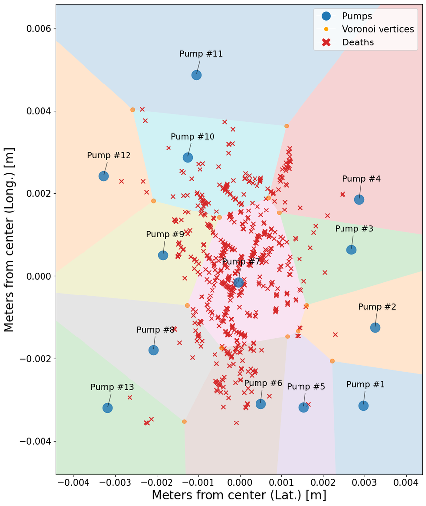

```python
# Visualize the Voronoi cells
nrows = 1
ncols = 1
f_size = 11
fig, axes = plt.subplots(nrows=nrows, ncols=ncols, figsize=(ncols*f_size, nrows*f_size*size_y/size_x))

axislabelsize = 20
axisticksize = 15
axislegendsize = 15
s_v_radius = 7
s_p_radius = 16
s_d_radius = 7

# Color Voronoi cells
for idx, region in enumerate(finite_regions):
    polygon = finite_vertices[region]
    plt.fill(*zip(*polygon),  alpha=0.2)

# Mark cell vertices
axes.scatter(finite_vertices[:,0], finite_vertices[:,1],
             c='tab:orange', s=s_v_radius**2, alpha=0.6, zorder=3)

# Mark pumps
axes.scatter(X_p, Y_p,
             c='C0', s=s_p_radius**2, alpha=0.8, zorder=3)

# Mark deaths
axes.scatter(X_d, Y_d, marker='x', s=s_d_radius**2, zorder=2)

# Annotate pumps
for _, p in pump.iterrows():
    axes.annotate('Pump #{0}'.format(p.OBJECTID),
                  xy=(p.lat_proj_rs, p.long_proj_rs), xycoords='data',
                  xytext=(-28, 30), textcoords='offset points', size='14',
                  arrowprops=dict(arrowstyle='-', color='black', alpha=0.6))

axes.set_xlabel('Meters from center (Lat.) [m]', fontsize=axislabelsize)
axes.set_ylabel('Meters from center (Long.) [m]', fontsize=axislabelsize)
axes.tick_params(axis='both', which='major', labelsize=axisticksize)

# Set border limits
mult = 1.35
axes.set_xlim(mult*min_x, mult*max_x)
axes.set_ylim(mult*min_y, mult*max_y)

# Create figure legend
handles = [
    Line2D([0], [0], marker='o', color='w', label='Pumps', markerfacecolor='C0', markersize=s_p_radius),
    Line2D([0], [0], marker='.', color='w', label='Voronoi vertices', markerfacecolor='orange', markersize=16),
    Line2D([0], [0], marker='X', color='w', label='Deaths', markerfacecolor='tab:red', markersize=16, lw=1)
]
axes.legend(handles=handles, loc='upper right', fontsize=axislegendsize)

plt.show()
```

```python
deaths_near_pumps = {pump_id: 0 for pump_id in pump.OBJECTID}


death_coords = np.vstack([X_d, Y_d]).T  # shape: (num_deaths, 2)

for region_index, region_vertices in enumerate(finite_regions):
    polygon_coords = [finite_vertices[v] for v in region_vertices]

    polygon = Polygon(polygon_coords)

    for death in death_coords:
        point = Point(death)  # Create a Point from death coordinates

        # If the point lies inside the polygon, count it
        if polygon.contains(point):
            # Add one death to the count for this Voronoi cell (pump)
            deaths_near_pumps[region_index + 1] += 1

dnp_arr = np.array(list(deaths_near_pumps.items())).T
```

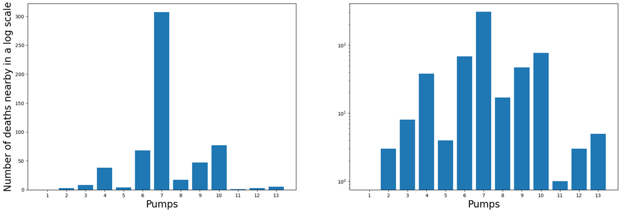

```python
nrows = 1
ncols = 2
fig, axes = plt.subplots(nrows=nrows, ncols=ncols, figsize=(ncols*11, nrows*7))

axislabelsize = 20
axisticksize = 15

# One normal and one log scaled axis
axes[1].set_yscale('log')

for i in range(ncols):
    axes[i].bar(dnp_arr[0], dnp_arr[1])

    plt.sca(axes[i])
    plt.xticks(dnp_arr[0], dnp_arr[0])

    axes[i].set_xlabel('Pumps', fontsize=axislabelsize)

axes[0].set_ylabel('Number of deaths nearby in a normal scale', fontsize=axislabelsize)
axes[0].set_ylabel('Number of deaths nearby in a log scale', fontsize=axislabelsize)


plt.show()
```

## Exercise 6

Create a death density map using 2D Kernel Density Estimation. Display the density and its contours on the map along with the pumps. What is the density value at each of the pumps? Pinpoint the possible source of the infection.

*Use the projected Cartesian coordinate system for this exercise.*

## Exercise 7

Create a GeoJSON object from the Voronoi cells, put the cells on the map, colored according to the number of deaths (like on a heatmap). Display the results in the notebook.

*[GeoJSON](http://geojson.org/) is a common format that is used in web applications. It is basically a simple key-value dictionary with a predefined structure for storing geographic information. Once loaded into Python, it behaves like a normal Python dictionary, thus creating or modifying it is quite straightforward. When reading or writing to a file, the `json` module is handy. The advice is to write a function that converts a list of coordinates from a polygon into a GeoJSON feature, then add it to your GeoJSON structure.*

## Exercise 8

(optional) Download the street network of the area of the deaths from OpenStreetMap using its [map API](https://wiki.openstreetmap.org/wiki/API_v0.6#Retrieving_map_data_by_bounding_box:_GET_.2Fapi.2F0.6.2Fmap). Use street segments given back by the API as edges of a street graph. Develop a method based on the cholera dataset to classify these edges into three categories:

- existed at the time of John Snow
- did not exist at the time of John Snow
- cannot decide

*You'll get the id of each node and way that falls within a bounding box with the GET method of the map API. Use the ids to retrieve the shapes with the help of the ways API.*

*The results will be in XML format. Find a good [XML parser](https://docs.python.org/2/library/xml.etree.elementtree.html#module-xml.etree.ElementTree) to navigate the structures.*

## Exercise 9

(optional)

Plot the streets on the map along with the pumps and the deaths colored by the results of the classification.